# Assessment: Exploring the Gapminder Dataset

Exercise 1. Life expectancy vs fertility - part 1 The Gapminder Foundation (www.gapminder.org) is a non-profit organization based in Sweden that promotes global development through the use of statistics that can help reduce misconceptions about global development.

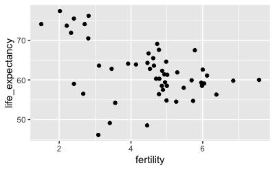

```r
library(dplyr)
library(ggplot2)
library(dslabs)
data(gapminder)
gapminder %>% filter(continent=="Africa" & year == 2012) %>%
  ggplot(aes(fertility, life_expectancy)) +
  geom_point()
```

Exercise 2. Life expectancy vs fertility - part 2 - coloring your plot Note that there is quite a bit of variability in life expectancy and fertility with some African countries having very high life expectancies. There also appear to be three clusters in the plot.

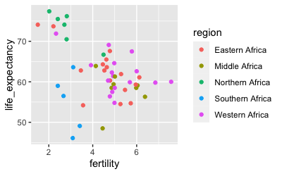

```r
library(dplyr)
library(ggplot2)
library(dslabs)
data(gapminder)
gapminder %>% filter(continent=="Africa" & year == 2012) %>%
  ggplot(aes(fertility, life_expectancy, color = region)) +
  geom_point()
```

Exercise 3. Life expectancy vs fertility - part 3 - selecting country and region While many of the countries in the high life expectancy/low fertility cluster are from Northern Africa, three countries are not.

```r
library(dplyr)
library(dslabs)
data(gapminder)
df <- gapminder %>%
  filter(continent=="Africa" & year == 2012 & fertility <=3 & life_expectancy>=70) %>%
  select(country, region)
```

Exercise 4. Life expectancy and the Vietnam War - part 1 The Vietnam War lasted from 1955 to 1975. Do the data support war having a negative effect on life expectancy? We will create a time series plot that covers the period from 1960 to 2010 of life expectancy for Vietnam and the United States, using color to distinguish the two countries. In this start we start the analysis by generating a table.

```r
library(dplyr)
library(dslabs)
data(gapminder)
years <- 1960:2010
countries <- c("United States", "Vietnam")
tab <- gapminder %>% filter(year %in% years & country %in% countries)
```

Exercise 5. Life expectancy and the Vietnam War - part 2 Now that you have created the data table in Exercise 4, it is time to plot the data for the two countries.

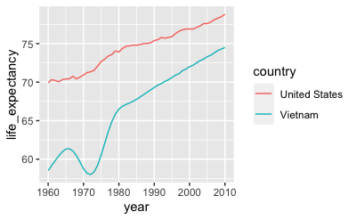

```r
p <- tab %>% ggplot(aes(x=year,y=life_expectancy,color=country)) + geom_line()
p
```

Exercise 5. Life expectancy and the Vietnam War - part 2 Now that you have created the data table in Exercise 4, it is time to plot the data for the two countries.

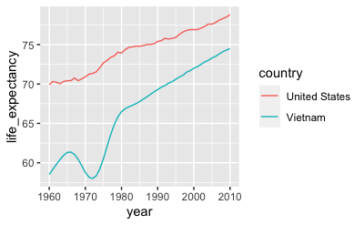

```r
p <- tab %>% ggplot(aes(x=year,y=life_expectancy,color=country)) + geom_line()
p
```

Exercise 6. Life expectancy in Cambodia Cambodia was also involved in this conflict and, after the war, Pol Pot and his communist Khmer Rouge took control and ruled Cambodia from 1975 to 1979. He is considered one of the most brutal dictators in history. Do the data support this claim?

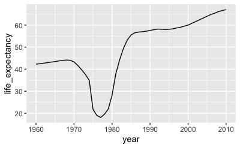

```r
library(dplyr)
library(ggplot2)
library(dslabs)
data(gapminder)
gapminder %>% filter(year >= 1960 & year <= 2010 & country == "Cambodia") %>%
  ggplot(aes(year, life_expectancy)) + geom_line()
```

Exercise 7. Dollars per day - part 1 Now we are going to calculate and plot dollars per day for African countries in 2010 using GDP data.

In the first part of this analysis, we will create the dollars per day variable.

```r
library(dplyr)
library(dslabs)
data(gapminder)
daydollars <- gapminder %>% mutate(dollars_per_day = gdp/population/365) %>% filter(continent == "Africa" & year == 2010 & !is.na(dollars_per_day))
```

Exercise 8. Dollars per day - part 2 Now we are going to calculate and plot dollars per day for African countries in 2010 using GDP data.

In the second part of this analysis, we will plot the smooth density plot using a log (base 2) x axis.

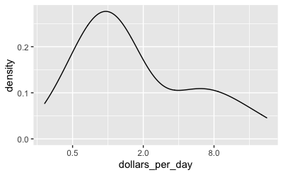

```r
daydollars %>% ggplot(aes(dollars_per_day)) + geom_density() + scale_x_continuous(trans = "log2")
```

Exercise 9. Dollars per day - part 3 - multiple density plots Now we are going to combine the plotting tools we have used in the past two exercises to create density plots for multiple years.

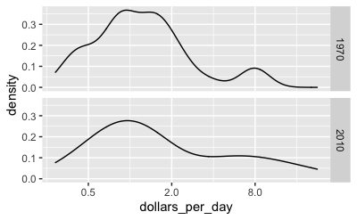

```r
library(dplyr)
library(ggplot2)
library(dslabs)
data(gapminder)
gapminder %>%
  mutate(dollars_per_day = gdp/population/365) %>%
  filter(continent == "Africa" & year %in% c(1970,2010) & !is.na(dollars_per_day)) %>%
  ggplot(aes(dollars_per_day)) +
  geom_density() +
  scale_x_continuous(trans = "log2") +
  facet_grid(year ~ .)
```

Exercise 10. Dollars per day - part 4 - stacked density plot Now we are going to edit the code from Exercise 9 to show a stacked density plot of each region in Africa.

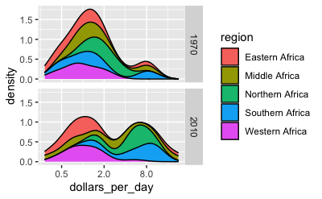

```r
library(dplyr)
library(ggplot2)
library(dslabs)
data(gapminder)

gapminder %>%
  mutate(dollars_per_day = gdp/population/365) %>%
  filter(continent == "Africa" & year %in% c(1970,2010) & !is.na(dollars_per_day)) %>%
  ggplot(aes(dollars_per_day, fill = region)) +
  geom_density(bw=0.5, position = "stack") +
  scale_x_continuous(trans = "log2") +
  facet_grid(year ~ .)
```

Exercise 11. Infant mortality scatter plot - part 1 We are going to continue looking at patterns in the gapminder dataset by plotting infant mortality rates versus dollars per day for African countries.

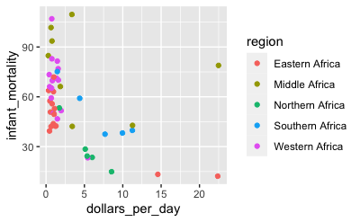

```r
library(dplyr)
library(ggplot2)
library(dslabs)
data(gapminder)
gapminder_Africa_2010 <- gapminder %>%
  mutate(dollars_per_day = gdp/population/365) %>%
  filter(continent == "Africa" & year == 2010 & !is.na(dollars_per_day) & !is.na(infant_mortality))

gapminder_Africa_2010 %>%  ggplot(aes(dollars_per_day, infant_mortality, color = region)) +
  geom_point()
```

Exercise 12. Infant mortality scatter plot - part 2 - logarithmic axis Now we are going to transform the x axis of the plot from the previous exercise.

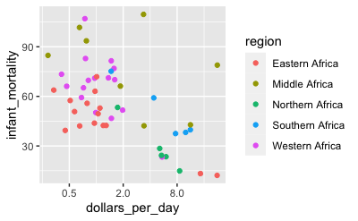

```r
gapminder_Africa_2010 %>%
  ggplot(aes(dollars_per_day, infant_mortality, color = region)) +
  geom_point() +
  scale_x_continuous(trans = "log2")
```

Exercise 13. Infant mortality scatter plot - part 3 - adding labels Note that there is a large variation in infant mortality and dollars per day among African countries.

As an example, one country has infant mortality rates of less than 20 per 1000 and dollars per day of 16, while another country has infant mortality rates over 10% and dollars per day of about 1.

In this exercise, we will remake the plot from Exercise 12 with country names instead of points so we can identify which countries are which.

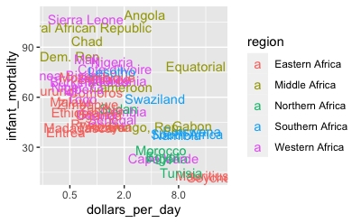

```r
gapminder_Africa_2010 %>%
  ggplot(aes(dollars_per_day, infant_mortality, color = region, label = country)) +
  geom_text() +
  scale_x_continuous(trans = "log2")
```

Exercise 14. Infant mortality scatter plot - part 4 - comparison of scatter plots Now we are going to look at changes in the infant mortality and dollars per day patterns African countries between 1970 and 2010.

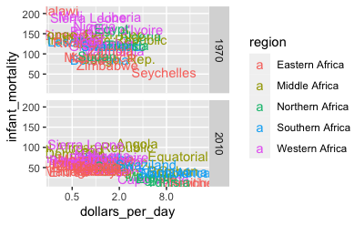

```r
library(dplyr)
library(ggplot2)
library(dslabs)
data(gapminder)
gapminder %>%
  mutate(dollars_per_day = gdp/population/365) %>%
  filter(continent == "Africa" & year %in% c(1970, 2010) & !is.na(dollars_per_day) & !is.na(infant_mortality)) %>%
  ggplot(aes(dollars_per_day, infant_mortality, color = region, label = country)) +
  geom_text() +
  scale_x_continuous(trans = "log2") +
  facet_grid(year~.)
```